# Bank Marketing Conversion

```r
knitr::opts_chunk$set(warning = FALSE, message = FALSE)
library(tidyverse)
library(plotly)
library(pROC)
library(broom)
library(caret)
# library(randomForest)
library(ranger)
```

## Overview

We are working with a dataset from a Portuguese bank. The data categorizes direct marketing efforts (phone calls) designed to sell term deposit products. The [dataset](https://archive.ics.uci.edu/ml/datasets/Bank+Marketing) was donated to UCI’s Machine Learning Repository.

The goal of this analysis is to use the data to tailor future marketing efforts. The “client” has a known cost per interaction, and would like to deploy those costs in scenarios that maximize the return on their investment.

### General Approach

We explore two modeling methods that can be used to estimate the exepcted value of customer contacts in future marketing campaigns. First, we apply a logistic regression that gives an easily interpertable model for scoring the likliehood that a customer subscribes; this can produce a continuous “expected customer value.”

Second, we build a random forest model that provides a more “black box” scoring model. Additionally, this model provides discrete categorizations rather than probabalistic estimates. This means that each cohort has a shared “expected value.”

To partially mitigate the starkness of this approach and the large percentage of customers categorized as not likely to subscribe to a term deposit, we apply a “multi-stage random forest model,” by building random forest models on the cohort of customers designiated as unlikely to subscribe to a term deposit. This allows both a more nuanced set of “expected customer values” and allows for the possibility of capturing a larger percentage of the customers who are likely to subscribe.

These approaches are far from exhaustive. They show, however, that analytic techniques can help banks to deploy scarce resources to higher-than-average value marketing targets.

### Deliverables

- Project Overview Document
- Shiny Application for stratifying and scoring future cohorts
  - Market to all
  - Market to some - Logistic Regression with different cutoffs
  - Market to some - Multi-level Random Forest Model
- Tutorial Discussing Technical Implementation of Logistic Regression and Random Forest Model

## Analysis

### Load Data

```r
# raw_data <- read_delim("data/bank-additional/bank-additional-full.csv", ";")
#
# names(raw_data) <- stringr::str_replace_all(names(raw_data), "[.]", "_")
raw_data <- readRDS("data/all_data.RDS")
all_data <- raw_data %>%
  mutate(job = str_replace_all(job, "[.-]", "")) %>%
  na.omit
```

### Training Data For Analysis

```r
set.seed(3456)
trainIndex <- createDataPartition(all_data$term_deposit, p = .25,
                                  list = FALSE,
                                  times = 1)
training_and_test_data <- all_data %>%
  mutate(
    education = case_when(
      education %in% c("basic.4y", "basic.6y", "illiterate") ~ "less.than.5.years",
      TRUE ~ education
    ),
    train_or_test = case_when(
      row_number() %in% trainIndex ~ "train",
      TRUE ~ "test"
    )
  ) %>%
  select(-nearZeroVar(.)) %>%
  select(-in_default) %>%
  mutate_at(
    vars(job, marital, education, housing_loan, personal_loan, contact, month, day_of_week, prior_outcome, term_deposit),
    funs(as_factor(.))) %>%
  mutate(term_deposit = fct_relevel(term_deposit, "yes", "no")) %>%
  group_by(train_or_test) %>%
  nest()
training_data <- training_and_test_data %>%
  filter(train_or_test == "train") %>%
  unnest() %>%
  select(-train_or_test)
testing_data <- training_and_test_data %>%
  filter(train_or_test == "test") %>%
  unnest() %>%
  select(-train_or_test)
```

### Logistic Regression

In this context, a negative co-efficient makes it more likely that someone will purchase a term_deposit (i.e. a positive number is “no purchase”).

```r
m1 <- glm(term_deposit ~ ., binomial, training_data)
summary(m1)
```

```
Call:
glm(formula = term_deposit ~ ., family = binomial, data = training_data)

Deviance Residuals:
    Min       1Q   Median       3Q      Max
-2.9478   0.2427   0.3201   0.4075   2.1784

Coefficients: (1 not defined because of singularities)
                               Estimate Std. Error z value Pr(>|z|)
(Intercept)                   3.211e+02  1.002e+03   0.321 0.748497
age                          -1.807e-03  4.213e-03  -0.429 0.667986
jobservices                  -2.463e-01  2.925e-01  -0.842 0.399774
jobadmin                     -2.874e-01  2.744e-01  -1.047 0.294950
jobbluecollar                 8.472e-03  2.784e-01   0.030 0.975727
jobtechnician                -3.752e-01  2.819e-01  -1.331 0.183231
jobretired                   -3.964e-01  2.996e-01  -1.323 0.185717
jobmanagement                -4.287e-01  2.934e-01  -1.461 0.143884
jobunemployed                -7.727e-02  3.413e-01  -0.226 0.820897
jobselfemployed              -2.177e-01  3.314e-01  -0.657 0.511236
jobunknown                   -2.026e-01  4.555e-01  -0.445 0.656432
jobentrepreneur              -5.981e-01  3.220e-01  -1.857 0.063252 .
jobstudent                   -4.912e-01  3.246e-01  -1.513 0.130211
maritalsingle                -1.483e-02  9.085e-02  -0.163 0.870343
maritaldivorced               2.853e-02  1.209e-01   0.236 0.813480
maritalunknown                2.310e-01  9.373e-01   0.246 0.805334
educationhigh.school          1.265e-01  1.415e-01   0.894 0.371321
educationbasic.9y             2.348e-01  1.488e-01   1.578 0.114502
educationprofessional.course  2.096e-01  1.613e-01   1.299 0.193844
educationunknown             -1.212e-01  1.910e-01  -0.634 0.525899
educationuniversity.degree    1.016e-01  1.417e-01   0.717 0.473423
housing_loanyes               1.267e-01  7.255e-02   1.746 0.080784 .
housing_loanunknown           3.228e-01  2.576e-01   1.253 0.210237
personal_loanyes             -1.111e-04  9.918e-02  -0.001 0.999106
personal_loanunknown                 NA         NA      NA       NA
contactcellular              -4.356e-01  1.292e-01  -3.371 0.000748 ***
monthjun                     -6.424e-01  1.548e-01  -4.149 3.34e-05 ***
monthjul                     -8.714e-01  1.402e-01  -6.217 5.06e-10 ***
monthaug                     -4.473e-01  1.805e-01  -2.478 0.013223 *
monthoct                     -8.241e-01  2.039e-01  -4.041 5.33e-05 ***
monthnov                     -3.988e-01  1.549e-01  -2.574 0.010043 *
```

[output cut: 10 more lines]

```
cons_price_idx               -3.774e-01  3.115e-01  -1.212 0.225694
cons_conf_idx                -4.647e-02  9.721e-03  -4.780 1.75e-06 ***
euribor3m                     5.160e-01  2.295e-01   2.248 0.024574 *
total_contacts                5.580e-02  1.841e-02   3.030 0.002443 **
year                         -1.424e-01  5.122e-01  -0.278 0.780969
---
Signif. codes:  0 ‘***’ 0.001 ‘**’ 0.01 ‘*’ 0.05 ‘.’ 0.1 ‘ ’ 1

(Dispersion parameter for binomial family taken to be 1)

    Null deviance: 7249.7  on 10296  degrees of freedom
Residual deviance: 5621.3  on 10252  degrees of freedom
AIC: 5711.3

Number of Fisher Scoring iterations: 6
```

Examine all statistically significant indicators (p.value < .05) in descending order of the absolute value of the coefficient.

```r
tidy(m1) %>%
  filter(p.value < .05) %>%
  arrange(desc(abs(estimate)))
```

| term | estimate | std.error | statistic | p.value |
| --- | --- | --- | --- | --- |
| monthmar | -1.53509488 | 0.252373130 | -6.082640 | 1.182196e-09 |
| prior_outcomesuccess | -1.50280941 | 0.138555576 | -10.846257 | 2.077596e-27 |
| monthdec | -1.04610356 | 0.382881346 | -2.732187 | 6.291536e-03 |
| monthjul | -0.87135631 | 0.140150469 | -6.217291 | 5.058097e-10 |
| monthoct | -0.82407292 | 0.203946863 | -4.040626 | 5.330880e-05 |
| monthsep | -0.78254758 | 0.224964229 | -3.478542 | 5.041489e-04 |
| monthjun | -0.64242062 | 0.154833300 | -4.149111 | 3.337683e-05 |
| euribor3m | 0.51597494 | 0.229522110 | 2.248040 | 2.457362e-02 |
| monthaug | -0.44730431 | 0.180531510 | -2.477708 | 1.322294e-02 |
| contactcellular | -0.43556978 | 0.129194683 | -3.371422 | 7.478124e-04 |

[output cut: 9 more lines]

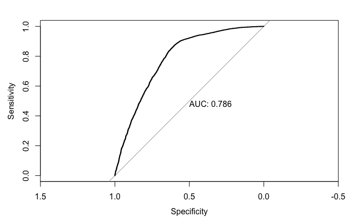

```r
# Predict
pred <- bind_rows("train" = training_data, "test" = testing_data, .id = "data") %>%
  mutate(
    pred = predict(m1, ., type = "response")) %>%
  mutate(decile = ntile(desc(pred), 10)) %>%
  select(data, term_deposit, pred, decile)
# ROC plot
pred %>%
  filter(data == "test") %>%
  roc(term_deposit ~ pred, .) %>%
  plot.roc(., print.auc = TRUE)
```

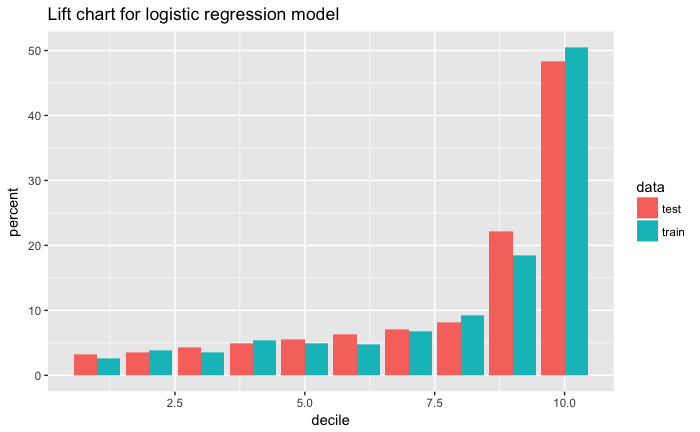

```r
# Lift plot
pred %>%
  group_by(data, decile) %>%
  summarize(percent = 100 * (mean(ifelse(term_deposit == "no", 0, 1)))) %>%
  ggplot(aes(decile, percent, fill = data)) + geom_bar(stat = "Identity", position = "dodge") +
  ggtitle("Lift chart for logistic regression model")
```

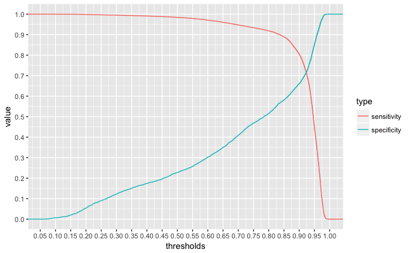

```r
# Sensitivity Vs Specificity
roc_output <- roc(term_deposit ~ pred, pred)
sensitivity <- data_frame(value = roc_output$sensitivities, type = "sensitivity", thresholds = roc_output$thresholds)
specificity <- data_frame(value = roc_output$specificities, type = "specificity", thresholds = roc_output$thresholds)
# roc <- data_frame(value = roc_output$sensitivities/roc_output$specificities, type = "roc", thresholds = roc_output$thresholds)
data_to_plot <- bind_rows(sensitivity, specificity)
ggplot(data = data_to_plot, mapping = aes(color = type, x = thresholds, y = value)) + geom_line() + scale_x_continuous(name = "thresholds", breaks = seq(0, 1, .05)) + scale_y_continuous(name = "value", breaks = seq(0, 1, .1))
```

```r
# Picke a cutoff where the specificity is similar to the specificity of the random forest model, so that you compare sensitivities with similar TNRs.
cutoff <- .88
sample_test_logistic <- testing_data %>%
  mutate(
    predicted = case_when(
      predict(m1, ., type = 'response') <= cutoff ~ "yes",
      TRUE ~ "no")
  )

confusion_matrix_logistic <- confusionMatrix(sample_test_logistic$predicted, sample_test_logistic$term_deposit)
confusion_matrix_logistic
```

```
Confusion Matrix and Statistics

          Reference
Prediction   yes    no
       yes  2168  4134
       no   1312 23277

               Accuracy : 0.8237
                 95% CI : (0.8194, 0.8279)
    No Information Rate : 0.8873
    P-Value [Acc > NIR] : 1

                  Kappa : 0.3487
 Mcnemar's Test P-Value : <2e-16

            Sensitivity : 0.62299
            Specificity : 0.84918
         Pos Pred Value : 0.34402
         Neg Pred Value : 0.94664
             Prevalence : 0.11265
         Detection Rate : 0.07018
   Detection Prevalence : 0.20401
      Balanced Accuracy : 0.73609

       'Positive' Class : yes
```

```r
prop.table(confusion_matrix_logistic$table)
```

```
          Reference
Prediction        yes         no
       yes 0.07018225 0.13382539
       no  0.04247192 0.75352044
```

### Random Forest Methodology Overview

```r
training_data_to_use <- training_data
ranger_model <- ranger(term_deposit ~  . , data = training_data_to_use )
trainctrl <- trainControl(verboseIter = TRUE, method="cv", number=3, savePredictions = TRUE, sampling = "down",
                          classProbs = TRUE)
caret_cv <- train(term_deposit ~ ., method = 'ranger', data = training_data_to_use, trControl = trainctrl, metric = 'Kappa', tuneLength = 5, importance = 'impurity')
```

```r
saveRDS(ranger_model, "ranger_model.RDS")
saveRDS(caret_cv, "caret_cv.RDS")
# ranger_model <- readRDS("ranger_model.RDS")
# caret_cv <- readRDS("caret_cv.RDS")
```

### Ranger Prediction

```r
sample_test_ranger <- testing_data %>%
  mutate(
    predicted = predictions(predict(ranger_model, .))
  )

confusion_matrix_ranger <- confusionMatrix(sample_test_ranger$predicted, sample_test_ranger$term_deposit)
confusion_matrix_ranger
```

```
Confusion Matrix and Statistics

          Reference
Prediction   yes    no
       yes   858   524
       no   2622 26887

               Accuracy : 0.8982
                 95% CI : (0.8947, 0.9015)
    No Information Rate : 0.8873
    P-Value [Acc > NIR] : 5.77e-10

                  Kappa : 0.3087
 Mcnemar's Test P-Value : < 2.2e-16

            Sensitivity : 0.24655
            Specificity : 0.98088
         Pos Pred Value : 0.62084
         Neg Pred Value : 0.91115
             Prevalence : 0.11265
         Detection Rate : 0.02778
   Detection Prevalence : 0.04474
      Balanced Accuracy : 0.61372

       'Positive' Class : yes
```

```r
prop.table(confusion_matrix_ranger$table)
```

```
          Reference
Prediction        yes         no
       yes 0.02777508 0.01696287
       no  0.08487909 0.87038296
```

### Downsampled Prediction

```r
sample_caret_cv <- testing_data %>%
  mutate(
    predicted = predict(caret_cv, .)
  )

confusion_matrix_ranger <- confusionMatrix(sample_caret_cv$predicted, sample_caret_cv$term_deposit)
confusion_matrix_ranger
```

```
Confusion Matrix and Statistics

          Reference
Prediction   yes    no
       yes  2228  4839
       no   1252 22572

               Accuracy : 0.8028
                 95% CI : (0.7983, 0.8072)
    No Information Rate : 0.8873
    P-Value [Acc > NIR] : 1

                  Kappa : 0.3198
 Mcnemar's Test P-Value : <2e-16

            Sensitivity : 0.64023
            Specificity : 0.82347
         Pos Pred Value : 0.31527
         Neg Pred Value : 0.94745
             Prevalence : 0.11265
         Detection Rate : 0.07212
   Detection Prevalence : 0.22877
      Balanced Accuracy : 0.73185

       'Positive' Class : yes
```

```r
prop.table(sample_caret_cv$table)
```

```
numeric(0)
```

```r
varImp(caret_cv)
```

```
ranger variable importance

  only 20 most important variables shown (out of 45)

                             Overall
euribor3m                    100.000
age                           51.643
year                          41.345
cons_conf_idx                 27.781
total_contacts                24.606
cons_price_idx                20.147
prior_outcomesuccess          12.331
housing_loanyes                8.264
contactcellular                8.076
educationhigh.school           6.648
day_of_weektue                 6.156
day_of_weekwed                 6.140
jobadmin                       6.134
educationuniversity.degree     6.119
maritalsingle                  6.056
personal_loanyes               6.052
jobbluecollar                  5.792
educationprofessional.course   5.543
day_of_weekthu                 5.459
day_of_weekfri                 5.427
```

### All Model Outcomes

```r
pred_all <- bind_rows("train" = training_data, "test" = testing_data, .id = "data") %>%
  mutate(
    logistic_predict_no = predict(m1, ., type = "response"),
    ranger_predict = predictions(predict(ranger_model, .)),
    downsample_predict = predict(caret_cv, .)
  )
saveRDS(pred_all, "predictions.RDS")
```

```r
summary_pred_all <- pred_all %>%
  mutate(
    number_of_rf_models = case_when(
      ranger_predict == "yes" & downsample_predict == "yes" ~ 2,
      ranger_predict == "yes" | downsample_predict == "yes" ~ 1,
      TRUE ~ 0
    ),
    optimized_cutoff_logistic = ifelse(logistic_predict_no <= cutoff, "yes", "no")
  ) %>%
  group_by(downsample_predict, optimized_cutoff_logistic, data) %>%
  summarize(
    median_logistic_prediction = round(median(logistic_predict_no), 2),
    average_logistic_prediction = round(mean(logistic_predict_no), 2),
    number_yes = sum(ifelse(term_deposit == "yes", 1, 0)),
    number_no = sum((ifelse(term_deposit == "no", 1, 0))),
    actual_yes_percentage = round(number_yes/n(), 2),
    total = n()
  ) %>%
  ungroup() %>%
  arrange(data, desc(downsample_predict))
  # arrange(data, desc(ninety_cutoff_logistic))
summary_pred_all
```

| downsample_predict | optimized_cutoff_logistic | data | median_logistic_prediction | average_logistic_prediction | number_yes | number_no | actual_yes_percentage | total |
| --- | --- | --- | --- | --- | --- | --- | --- | --- |
| no | no | test | 0.95 | 0.95 | 1129 | 21617 | 0.05 | 22746 |
| no | yes | test | 0.86 | 0.85 | 123 | 955 | 0.11 | 1078 |
| yes | no | test | 0.92 | 0.92 | 183 | 1660 | 0.10 | 1843 |
| yes | yes | test | 0.68 | 0.63 | 2045 | 3179 | 0.39 | 5224 |
| no | no | train | 0.95 | 0.95 | 112 | 7219 | 0.02 | 7331 |
| no | yes | train | 0.86 | 0.83 | 3 | 404 | 0.01 | 407 |
| yes | no | train | 0.92 | 0.92 | 305 | 462 | 0.40 | 767 |
| yes | yes | train | 0.68 | 0.63 | 740 | 1052 | 0.41 | 1792 |